# Practical: hierarchically modeling environmental responses

Physalia workshop on GLLVMs

Bert van der Veen

# Description

So far we have focused on answering the question “what environmental conditions do species prefer?”. VGLM(M)s estimate species responses to the environment, so the coefficients and statistical uncertainties help us to answer the question. A good part of community ecology is more occupied with answering the question “why do species prefer particular environmental conditions?” using functional traits.

The idea is that species’ physical characteristics are the driver of their ability to thrive in particular conditions. In the lecture, I took the example of leaf thickness of plants, or color of the fur for the snowshoe hare. Of course, there is individual variation in traits; some individuals have thicker leaves than others, or the fur color differs from hare to hare, but as we are analysing data at the species-level we will ignore intra-specific trait variation for the moment (also, few models currently exist that can incorporate it)!

Traditionally, community ecologists would explore this question using community weighted means in combination with a constrained ordination. Analysing data in that manner has significant flaws, which two-step approaches usually do (for example, propagation of uncertainty, but also you will simply get the estimators wrong when your data is non-normally distributed, as it often is).

As explained in the lecture, this approach of using traits to inform how species respond to the environment has long been referred to as the “fourth-corner problem”. In a statistical model, we pose this as an interaction of traits and environment, so that the interaction coefficients explain if species with a particular trait respond differently to the environment. That makes the models an extension of what we looked at yesterday.

# Part I

## Data

Because we need functional traits in this exercise, we are now a bit more limited in the datasets that we can use. Today’s lecture used the Alpine2 (traits) and fungi (traits and phylogeny) data; the following datasets include species response data, environmental variables, and traits:

1. Carabid beetles (“beetles”, abundance)
2. French Alpine plants (“Alpine2”, presence-absence; used in the lecture)
3. Wood-inhabiting fungi (“fungi”, presence-absence, also has a phylogeny; used in the lecture)
4. Hunting spiders (“spider”, counts in `mvabund`)

## Background

Start by choosing a dataset, I will choose a different dataset this time, because the waddensea data has no traits. Instead, I use the Beetles data that is also used in [Niku et al. (2021)](https://onlinelibrary.wiley.com/doi/full/10.1002/env.2683) for developing the fourth-corner approach in the `gllvm` package. This first code chunk does some formatting to make sure that the data is in the right format.

```r
# Response data
Y <- t(read.csv("../../data/beetlesY.csv"))
colnames(Y) <- Y[2,]
Y<-Y[-c(1:2),-c(1,70:71)]
Y <- as.data.frame(apply(Y,2,as.integer))

# Environmental predictors
X <- read.csv("../../data/beetlesX.csv")[,-c(1:5)]
X <- as.data.frame(apply(X,2,as.numeric))
X$Sampling.year <- X$Sampling.year - min(X$Sampling.year)
X$Texture <- as.factor(X$Texture)

# Traits
TR  <- read.csv("../../data/beetlesTR.csv")
row.names(TR) <- TR$SPECIES
TR <- TR[,-c(1:3)]
# Traits to categorical
# Removing question marks, not ideal
TR[,c("CLG","CLB","WIN","PRS","OVE","FOA","DAY","BRE","EME","ACT")] <- apply(TR[,c("CLG","CLB","WIN","PRS","OVE","FOA","DAY","BRE","EME","ACT")],2,function(x)as.factor(gsub("\\?.*","",x)))

# Data standardization
X <- scale(model.matrix(~.,X))[,-1] # environmental variables
TR <- scale(model.matrix(~.,TR))[,-1] # species traits
```

A fourth-corner model in `gllvm` is fitted by providing environment and trait covariates simultaneously. The arguments passed to the `formula` argument correspond to the (hierarchical) equation for species responses; trait-environment interaction coefficients are the same for all species, environment terms are the same for all species, random effects are species-specific. The effects that are the same across all species could also be specified via `row.eff`. That means the specification of the `formula` argument deviates a little from that of the previous models that we have fitted, but the principles are largely the same. We can also use the `beta0comm` option if we want to assume a global intercept (rather than the default of species-specific intercepts).

Niku et al. used only a few covariates, so I will do the same here:

```r
library(gllvm)
model1 <- gllvm(y = Y, X = X, TR = TR,
                formula = ~ Management + Elevation + pH + Moist + (Management + Elevation + pH + Moist):(LPH+ LTL + OVE2 + BRE2 + BRE3),
                family = "negative.binomial", num.lv = 0)
```

This first model fits rather quickly: there are only a few coefficients included as it excludes species-specific responses to the environment. It corresponds to the equation:

$$\begin{equation}
\boldsymbol{\beta}_j = \boldsymbol{\beta}_k +
\text{tr}_j\textbf{B}_{x,tr}
\end{equation}$$

This means that there is still a common component to species’ environmental responses, $\boldsymbol{\beta}_k$, but that the deviation from that for every species is fully determined by the traits $\text{tr}_j\textbf{B}_{x,tr}$.

We can extract the **fourth-corner** coefficients and have a look at them:

```r
(fourth <- gllvm:::getFourthCorner(model1))
```

```
##                   LPH        LTL         OVE2       BRE2       BRE3
## Management -0.5979569 -0.5262606 -0.361046809 -1.1082730  0.2928644
## Elevation   0.2065903  0.2250597  0.009921852  0.4945497 -0.2885085
## pH         -0.1469962 -0.1407453 -0.630019360 -0.5238971 -0.1119216
## Moist      -0.2351518 -0.1192479  0.519740026 -0.2885463 -0.9955421
```

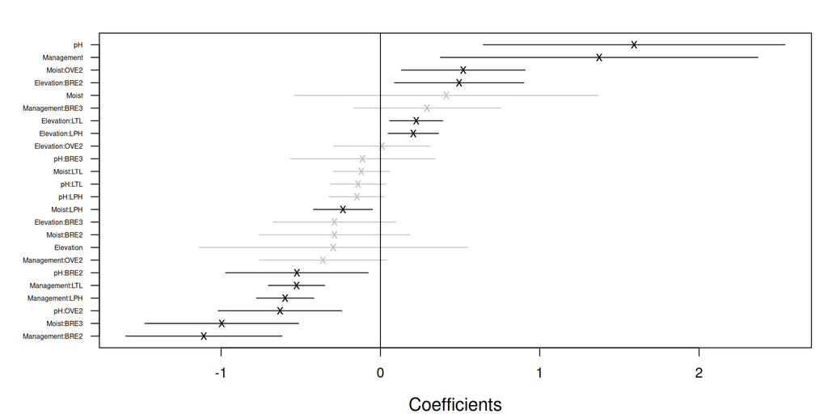

```r
coefplot(model1)
```

The `summary` also reports the interaction coefficients:

```r
summary(model1)
```

```
##
## Call:
## gllvm(y = Y, X = X, TR = TR, formula = ~Management + Elevation +
##     pH + Moist + (Management + Elevation + pH + Moist):(LPH +
##     LTL + OVE2 + BRE2 + BRE3), family = "negative.binomial",
##     num.lv = 0)
##
## Family:  negative.binomial
##
## AIC:  19216.8 AICc:  19225.75 BIC:  20286.46 LL:  -9448 df:  160
##
## Informed LVs:  0
## Constrained LVs:  0
## Unconstrained LVs:  0
##
## Formula:  ~Management+Elevation+pH+Moist+Management:LPH+Management:LTL+Management:OVE2+Management:BRE2+Management:BRE3+Elevation:LPH+Elevation:LTL+Elevation:OVE2+Elevation:BRE2+Elevation:BRE3+pH:LPH+pH:LTL+pH:OVE2+pH:BRE2+pH:BRE3+Moist:LPH+Moist:LTL+Moist:OVE2+Moist:BRE2+Moist:BRE3
## LV formula:  ~ 0
## Row effect:  ~ 1
##
## Coefficients predictors:
##                  Estimate Std. Error z value Pr(>|z|)
## Management       1.373247   0.508378   2.701 0.006908 **
## Elevation       -0.295602   0.431017  -0.686 0.492825
## pH               1.592792   0.483165   3.297 0.000979 ***
## Moist            0.414023   0.485761   0.852 0.394037
## Management:LPH  -0.597957   0.091795  -6.514 7.32e-11 ***
## Management:LTL  -0.526261   0.090184  -5.835 5.37e-09 ***
## Management:OVE2 -0.361047   0.203324  -1.776 0.075778 .
## Management:BRE2 -1.108273   0.250156  -4.430 9.41e-06 ***
## Management:BRE3  0.292864   0.234503   1.249 0.211712
## Elevation:LPH    0.206590   0.080667   2.561 0.010436 *
## Elevation:LTL    0.225060   0.084908   2.651 0.008034 **
## Elevation:OVE2   0.009922   0.154901   0.064 0.948928
## Elevation:BRE2   0.494550   0.207294   2.386 0.017045 *
## Elevation:BRE3  -0.288509   0.196838  -1.466 0.142726
## pH:LPH          -0.146996   0.089709  -1.639 0.101299
## pH:LTL          -0.140745   0.089763  -1.568 0.116888
## pH:OVE2         -0.630019   0.197777  -3.186 0.001445 **
## pH:BRE2         -0.523897   0.228168  -2.296 0.021670 *
## pH:BRE3         -0.111922   0.231359  -0.484 0.628558
## Moist:LPH       -0.235152   0.094516  -2.488 0.012848 *
## Moist:LTL       -0.119248   0.090341  -1.320 0.186843
## Moist:OVE2       0.519740   0.198074   2.624 0.008691 **
## Moist:BRE2      -0.288546   0.240339  -1.201 0.229914
## Moist:BRE3      -0.995542   0.245695  -4.052 5.08e-05 ***
## ---
## Signif. codes:  0 '***' 0.001 '**' 0.01 '*' 0.05 '.' 0.1 ' ' 1
```

The following might be a more intuitive visualization, though:

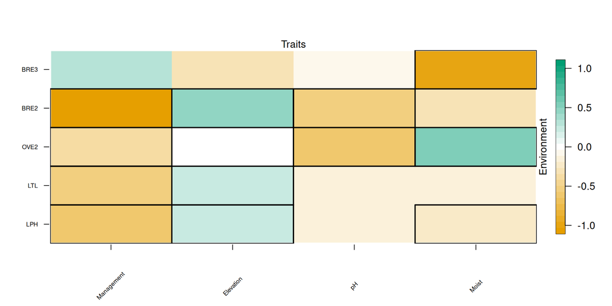

```r
# extract standard errors
model1temp <- model1
model1temp$params$B <- model1$sd$B
sds <- gllvm:::getFourthCorner(model1temp) # little trick to arrange the standard errors
LI = t(fourth+sds*qnorm(1-0.95))
UI = t(fourth+sds*qnorm(0.95))
a = max(abs(fourth))
fields::image.plot(1:nrow(fourth),1:ncol(fourth), fourth, axes=F, ylab=NA, xlab=NA, col = colorRampPalette(c("#E69F00","white","#009E73"))(29), breaks =seq(-a,a,length.out=30), legend.width=1, zlim=range(fourth))
mtext("Traits", 3)
mtext("Environment", 4)
text(1:nrow(fourth), -.6, srt = 45, labels = rownames(fourth), xpd = TRUE, cex = 0.6)
axis(1, label=F)
axis(2, 1:ncol(fourth), colnames(fourth), las=1, cex.axis = 0.6)
box(col="white", lwd=3)
cells_to_outline <- which(((LI>0 & UI>0) | (LI<0 & UI<0)), arr.ind = TRUE)

for (cell in 1:nrow(cells_to_outline)){
  x <- cells_to_outline[cell, 1]
  y <- cells_to_outline[cell, 2]
  x_vals <- c(y - 0.5, y + 0.5, y + 0.5, y - 0.5)  # X coordinates of the rectangle corners
  y_vals <- c(x - 0.5, x - 0.5, x + 0.5, x + 0.5)  # Y coordinates of the rectangle corners

polygon(x_vals, y_vals, col = NA, border = "black", lwd = 2)
}
```

The previous assumption of species’ responses fully due to traits is fine if the right traits are included, but if the chosen traits are not important to determining species’ environmental responses, it will result in lack-of-fit. So, in this next model we relax that assumption by also including species-specific random effects. We do need to run the model a few times, as it includes a lot of effects and does not always converge well.

```r
model2 <- gllvm(y = Y, X = X, TR = TR,
                formula = ~ Management + Elevation + pH + Moist + (Management + Elevation + pH + Moist):(LPH+ LTL + OVE2 + BRE2 + BRE3) + (0+Management + Elevation + pH + Moist|1),
                family = "negative.binomial", num.lv = 0, n.init = 3)
```

Similar as in the previous models we can plot the species-specific responses with `randomCoefPlot`.

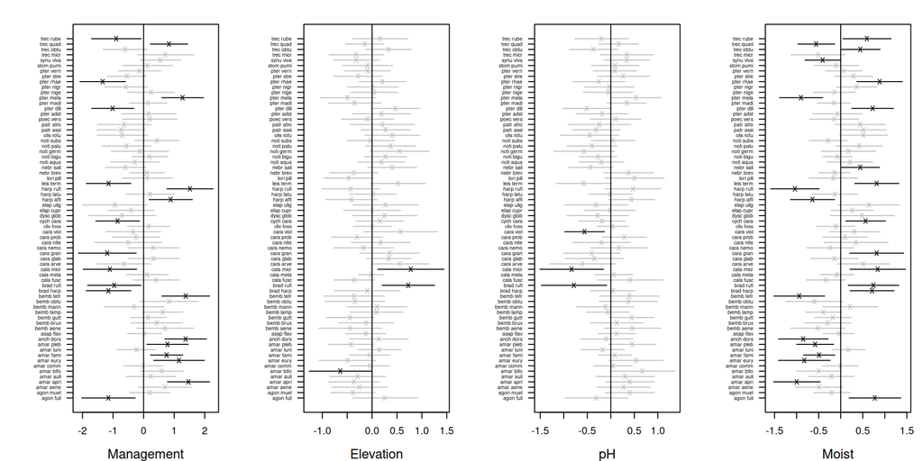

```r
# there is a little bug in the software, this first line circumvents that. Will be fixed in the upcoming CRAN submission
model2$randomX <- model2$Xrandom <- NULL
randomCoefplot(model2)
```

and, our fourth-corner coefficients may have changed, so we want to recreate our plot of those:

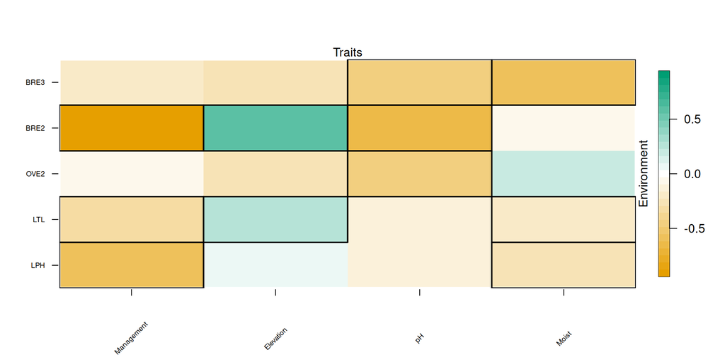

```r
fourth <- gllvm:::getFourthCorner(model2)
# extract standard errors
model2temp <- model2
model2temp$params$B <- model2$sd$B
sds <- gllvm:::getFourthCorner(model2temp) # little trick to arrange the standard errors
LI = t(fourth+sds*qnorm(1-0.95))
UI = t(fourth+sds*qnorm(0.95))
a = max(abs(fourth))
fields::image.plot(1:nrow(fourth),1:ncol(fourth), fourth, axes=F, ylab=NA, xlab=NA, col = colorRampPalette(c("#E69F00","white","#009E73"))(29), breaks =seq(-a,a,length.out=30), legend.width=1, zlim=range(fourth))
mtext("Traits", 3)
mtext("Environment", 4)
text(1:nrow(fourth), -.6, srt = 45, labels = rownames(fourth), xpd = TRUE, cex = 0.6)
axis(1, label=F)
axis(2, 1:ncol(fourth), colnames(fourth), las=1, cex.axis = 0.6)
box(col="white", lwd=3)
cells_to_outline <- which(((LI>0 & UI>0) | (LI<0 & UI<0)), arr.ind = TRUE)

for (cell in 1:nrow(cells_to_outline)){
  x <- cells_to_outline[cell, 1]
  y <- cells_to_outline[cell, 2]
  x_vals <- c(y - 0.5, y + 0.5, y + 0.5, y - 0.5)  # X coordinates of the rectangle corners
  y_vals <- c(x - 0.5, x - 0.5, x + 0.5, x + 0.5)  # Y coordinates of the rectangle corners

polygon(x_vals, y_vals, col = NA, border = "black", lwd = 2)
}
```

The effects have changed a little bit; can you spot the differences?

Finally, we can use `anova` to test if our species’ responses really depend on these traits. So, we fit a VGLMM similarly to last exercise, without the trait effects, and compare to the model that we just fitted:

```r
model3 <- gllvm(y = Y, X = X,
                formula = ~ (0+Management + Elevation + pH + Moist|1),
                family = "negative.binomial", num.lv = 0, n.init = 3)
anova(model2, model3)
```

```
## Model  1 :  y ~ NULL
## Model  2 :  ~ Management + Elevation + pH + Moist + (Management + Elevation + pH + Moist):(LPH + LTL + OVE2 + BRE2 + BRE3)
```

```
##   Resid.Df       D Df.diff     P.value
## 1     5766  0.0000       0
## 2     5746 82.7686      20 1.32383e-09
```

The models differ by 20 parameters, as indicated by the “df.diff” output. The resulting test is statistically significant; we conclude that species’ responses to the environment really do depend on these traits.

## Tasks

Suggestions for this practical:

1. Fit the models shown to your choice of dataset. You can experiment with including/excluding traits or environmental variables to see how it changes the results.
2. Try to make ecological sense of the fourth-corner coefficients. Don’t forget that the species-common effects are also present as shown by `summary`
3. Use `anova` to test the environment-trait hypothesis. You can also try using information criteria with `AIC`, `BIC` or `AICc`

# Part II

## Background

**Please be advised that the following models in this part of the practical may take some time to fit.**

The above model incorporates traits, but assumes that species are independent. We are now starting on our journey to fitting JSDMs that incorporate correlation of species. Here, we do not use latent variables yet, we assume that there is some additional information that can explain the co-occurrence of species: a phylogeny. This information can help to improve our prediction of species’ distribution. The beetles dataset does not include phylogenetic information, and finding published data with a good phylogeny is challenging, so we are restricted to a single dataset now. It is included in the package already, which makes loading it a bit easier.

```r
data(fungi, package = "gllvm")
Y2 <- fungi$Y
X2 <- fungi$X
X2 <- data.frame(lapply(X2, function(x)if(is.numeric(x)){scale(x)}else{as.factor(x)}))
tree <- fungi$tree
covMat<- ape::vcv(tree)
distMat <- ape::vcv(tree)
TR <- fungi$TR
colnames(TR)[8] <- "Sp.log.vol" # funky column name needs to be changed
```

We explore the data a little:

```r
any(rowSums(Y2)==0)
```

```
## [1] FALSE
```

```r
dim(Y2)
```

```
## [1] 1666  215
```

```r
colnames(X2)
```

```
## [1] "DBH.CM"    "AVERDP"    "CONNECT10" "TEMPR"     "PRECIP"    "log.AREA"
## [7] "REGION"    "RESERVE"
```

```r
colnames(TR)
```

```
## [1] "PC1"        "PC2"        "PC3"        "PC1.1"      "PC1.2"
## [6] "PC1.3"      "FB.type"    "Sp.log.vol" "Lifestyle"
```

This is a binary dataset by [Abrego et al. (2022)](https://besjournals.onlinelibrary.wiley.com/doi/full/10.1111/1365-2745.13839), of 215 wood inhabiting fungi inhabiting 1666 logs. `TR` includes the trait covariates, and `X` includes environmental variables related to the forest, or the deadwood, that the fungi occurred in/on. First, we will fit a model without phylogeny but with traits, and including “REGION” and “RESERVE” as random row effects to account for the nested design. We will use a couple tricks to speed up fitting the model: parallel computation (because I am impatient!).

```r
TMB::openmp(parallel::detectCores()-1, autopar = TRUE, DLL = "gllvm")
```

```
## gllvm
##    11
## attr(,"autopar")
## [1] TRUE
```

```r
model4 <- gllvm(Y2, X = X2, TR = TR, formula = ~DBH.CM+AVERDP+CONNECT10+TEMPR+PRECIP+
                  (DBH.CM+AVERDP+CONNECT10+TEMPR+PRECIP):(PC1.1+PC1.2+PC1.3),
                row.eff = ~(1|REGION/RESERVE), studyDesign =  X2[,c("REGION","RESERVE")],
                num.lv = 0, family = "binomial", sd.errors = FALSE,
                optim.method = "L-BFGS-B")
```

This model does not include species-specific random effects yet, so should fit reasonably quickly. The included “traits” are Principal Components extracted from the original trait matrix, in order to a-priori reduce complexity of the model. Be careful when playing around: with these dataset dimensions the models start using loads of RAM, and when you run out of RAM R will crash, which can quickly happen when we add more traits. In general, when working with large datasets and complex models, using a server for more computing power is advisable.

We can examine the fourth corner coefficients:

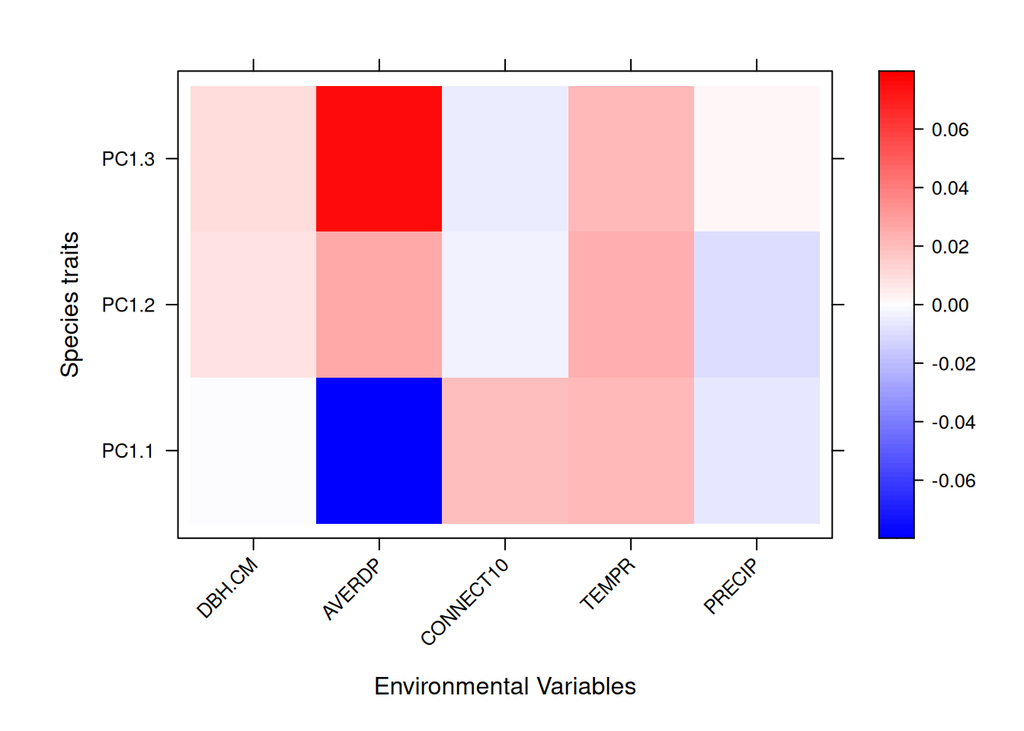

```r
library(lattice)
fourth <- model4$fourth.corner # the coefficients
a <- max(abs(fourth))
colort <- colorRampPalette(c("blue", "white", "red"))
plot.4th <- levelplot((as.matrix(fourth)), xlab = "Environmental Variables",
                      ylab = "Species traits", col.regions = colort(100), cex.lab = 1.3,
                      at = seq(-a, a, length = 100), scales = list(x = list(rot = 45)))
plot.4th
```

Excellent! The trait-environment interaction coefficients have been included, and visualized. You can also examine them using the model’s `summary`. With this model we again assumed that species’ responses to the environment are fully determined by species’ traits. Usually, we do not know if we have measured the right traits, so incorporating “residual” information in species’ responses to the environmental covariates is vital. We relax our assumption by fitting another model (this might take a little). To speed it up further we combine this with a slightly rougher approximation to the log-likelihood (`Ab.struct = "diagonal"`):

```r
model5 <- gllvm(Y2, X = X2, TR = TR, formula = ~DBH.CM+AVERDP+CONNECT10+TEMPR+PRECIP+
                  (DBH.CM+AVERDP+CONNECT10+TEMPR+PRECIP):(PC1.1+PC1.2+PC1.3),
                randomX = ~DBH.CM+AVERDP+CONNECT10+TEMPR+PRECIP,
                row.eff = ~(1|REGION/RESERVE), studyDesign =  X2[,c("REGION","RESERVE")],
                num.lv = 0, family = "binomial", sd.errors = FALSE,
                optim.method = "L-BFGS-B", Ab.struct = "diagonal", maxit=1e5)
```

this formulation ensures that the relevant correlations between species’ random effects are incorporated, which we can also examine with `summary`. Before we do that, we will add the final component to our model; the phylogeny. The `gllvm` package broadly implements phylogenetic mixed-effects models, which can also be used to fit models for traits or individuals (i.e., where traits are the response variables), but here we focus on our species data. Phylogenetic random effects make the model considerably more computer intensive (complex), and there are a range of considerations that we need to make when fitting it. In particular, the nearest neighbour approximation and the ordering of the species. There are various ways to find the “optimal” setting for both those things, which we will not go further into here (but ask if you want to know!). For further details see [the corresponding vignette in the package](https://jenniniku.github.io/gllvm/articles/vignette7.html). For the following models, you will need at least 30 minutes computing time. A smaller number of nearest neighbours will fit the model more quickly, but lead to less accurate results. Mind you, this is incredibly fast; it took the original authors ten days with the Hmsc R-package. For the exercises, you can reduce this further by (e.g.,) subsetting the data and fitting the models to a smaller number of species and sites.

```r
e <- eigen(covMat)$vectors[,1]
ord <- gllvm:::findOrder(covMat = covMat, distMat = distMat, nn = 15, order = order(e))$order
spec.ord <- colnames(covMat)[ord]
model6 <- gllvm(Y2[,spec.ord], X = X2, TR = TR, formula = ~DBH.CM+AVERDP+CONNECT10+TEMPR+PRECIP+
                  (DBH.CM+AVERDP+CONNECT10+TEMPR+PRECIP):(PC1.1+PC1.2+PC1.3),
                randomX = ~DBH.CM+AVERDP+CONNECT10+TEMPR+PRECIP,
                row.eff = ~(1|REGION/RESERVE), studyDesign =  X2[,c("REGION","RESERVE")],
                num.lv = 0, family = "binomial", sd.errors = FALSE,
                optim.method = "L-BFGS-B", Ab.struct = "MNdiagonal", maxit = 1e5,
                colMat = list(covMat[spec.ord, spec.ord], dist = distMat[spec.ord, spec.ord]), colMat.rho.struct = "term", nn.colMat = 15)
```

Let’s also calculate the standard error for our “final” model, but post model fitting. This is a useful strategy if you have a complex model, or if you are going through a model comparison procedure, as standard error calculation can take a significant amount of time, depending on the exact model structure:

```r
ses <- se(model6)
model6$sd <- ses$sd
model6$Hess <- ses$Hess
```

We can examine the phylogenetic signal with `summary` and plot the species-specific random effects (without trait effects) jointly with the phylogeny. We first need to calculate standard errors to do that:

```r
summary(model6)
```

```
##
## Call:
## gllvm(y = Y2[, spec.ord], X = X2, TR = TR, formula = ~DBH.CM +
##     AVERDP + CONNECT10 + TEMPR + PRECIP + (DBH.CM + AVERDP +
##     CONNECT10 + TEMPR + PRECIP):(PC1.1 + PC1.2 + PC1.3), family = "binomial",
##     num.lv = 0, studyDesign = X2[, c("REGION", "RESERVE")], colMat = list(covMat[spec.ord,
##         spec.ord], dist = distMat[spec.ord, spec.ord]), colMat.rho.struct = "term",
##     row.eff = ~(1 | REGION/RESERVE), sd.errors = FALSE, randomX = ~DBH.CM +
##         AVERDP + CONNECT10 + TEMPR + PRECIP, optim.method = "L-BFGS-B",
##     Ab.struct = "MNdiagonal", maxit = 1e+05, nn.colMat = 15)
##
## Family:  binomial
##
## AIC:  104177.9 AICc:  104178.2 BIC:  106950.6 LL:  -51832 df:  257
##
## Informed LVs:  0
## Constrained LVs:  0
## Unconstrained LVs:  0
##
## Formula:  ~DBH.CM+AVERDP+CONNECT10+TEMPR+PRECIP+DBH.CM:PC1.1+DBH.CM:PC1.2+DBH.CM:PC1.3+AVERDP:PC1.1+AVERDP:PC1.2+AVERDP:PC1.3+CONNECT10:PC1.1+CONNECT10:PC1.2+CONNECT10:PC1.3+TEMPR:PC1.1+TEMPR:PC1.2+TEMPR:PC1.3+PRECIP:PC1.1+PRECIP:PC1.2+PRECIP:PC1.3
## LV formula:  ~ 0
## Row effect:  ~(1 | REGION/RESERVE)
##
##  Multispecies random effects:
##  Name      Signal Variance Std.Dev Corr
##  DBH.CM    0.0000 0.0021   0.0458
##  AVERDP    1.0000 0.1524   0.3904   0.0027
##  CONNECT10 0.0057 0.0129   0.1134  -0.0072  0.0157
##  TEMPR     0.8196 0.0617   0.2484  -0.3752 -0.0239  0.8866
##  PRECIP    0.7771 0.0319   0.1785   0.7570 -0.3581 -0.2738 -0.5987
##
##  Random effects:
##  Name                       Variance Std.Dev
##  (Intercept)|RESERVE:REGION 0.0170   0.1305
##  (Intercept)|REGION         0.0132   0.1149
##
## Coefficients predictors:
##                  Estimate Std. Error z value Pr(>|z|)
## DBH.CM           0.149781   0.006342  23.618  < 2e-16 ***
## AVERDP          -0.298195   0.089524  -3.331 0.000866 ***
## CONNECT10       -0.032677   0.034100  -0.958 0.337930
## TEMPR            0.177535   0.067104   2.646 0.008153 **
## PRECIP          -0.008470   0.053733  -0.158 0.874747
## DBH.CM:PC1.1    -0.006070   0.006377  -0.952 0.341156
## DBH.CM:PC1.2     0.009429   0.006192   1.523 0.127831
## DBH.CM:PC1.3     0.007808   0.006444   1.212 0.225626
## AVERDP:PC1.1    -0.043888   0.021958  -1.999 0.045635 *
## AVERDP:PC1.2     0.021538   0.019210   1.121 0.262207
## AVERDP:PC1.3    -0.054608   0.017763  -3.074 0.002110 **
## CONNECT10:PC1.1 -0.005443   0.012085  -0.450 0.652461
## CONNECT10:PC1.2 -0.002600   0.011844  -0.220 0.826259
## CONNECT10:PC1.3  0.010576   0.012136   0.871 0.383517
## TEMPR:PC1.1      0.035625   0.017942   1.986 0.047078 *
## TEMPR:PC1.2      0.013784   0.015427   0.893 0.371605
## TEMPR:PC1.3      0.005346   0.016292   0.328 0.742786
## PRECIP:PC1.1     0.008528   0.014081   0.606 0.544783
## PRECIP:PC1.2     0.004759   0.012763   0.373 0.709230
## PRECIP:PC1.3     0.030009   0.012997   2.309 0.020943 *
## ---
## Signif. codes:  0 '***' 0.001 '**' 0.01 '*' 0.05 '.' 0.1 ' ' 1
```

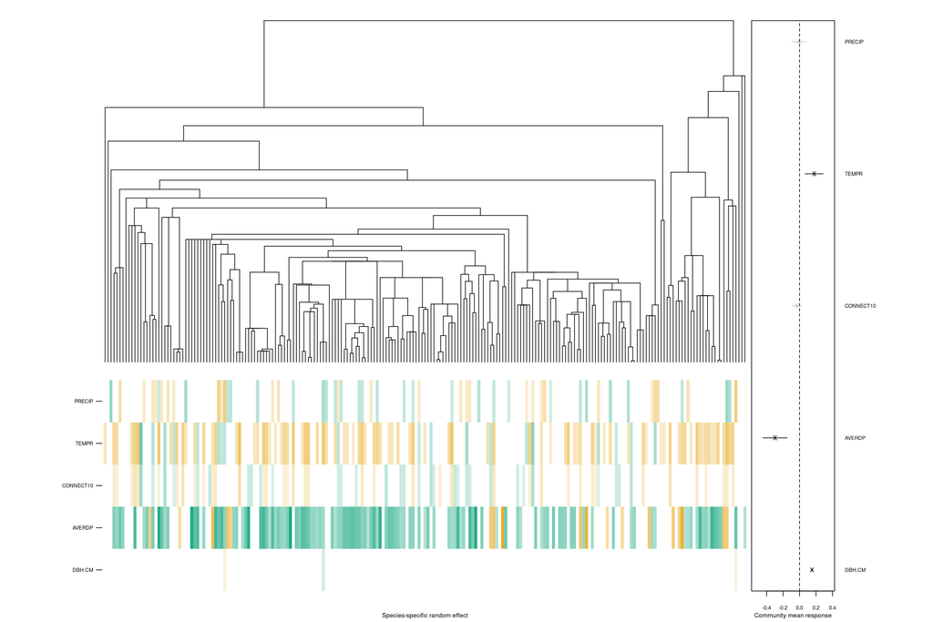

```r
phyloplot(model6, tree = tree)
```

and plot the associations due to the environmental variables and phylogeny:

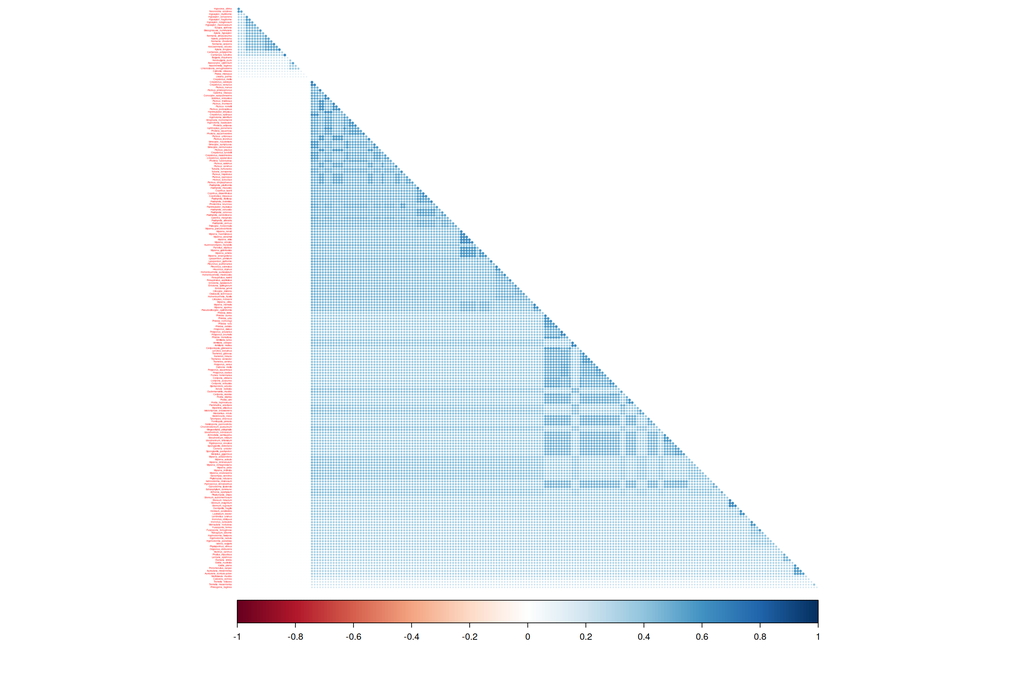

```r
library(Matrix)
corrplot::corrplot(cov2cor(getEnvironCov(model6)$cov), type = "lower", order = "AOE", diag = FALSE, tl.pos = "l", tl.cex = 0.2, addgrid.col = NA)
```